# act_report

## Act Report

#### Chukwuma Anthony Nwachukwu

I tried an analysis where I sort the sort the True values for each image prediction, get the max confidence levels on each role and made a column of the resulting dog breed as correct prediction.

[figure not shown]

#### Maturity plots

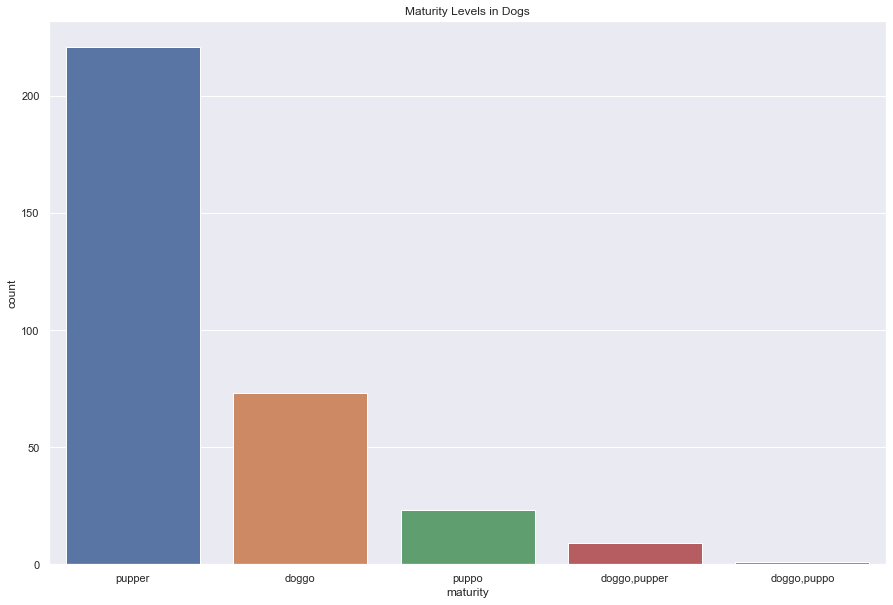

- pupper was the most occuring maturity stages for dogs in the dataset with value **221**
- doggo,puppo has the least occurance with value **1*

The exploring the relationship between maturity with retweets and like had a suprising outcome;

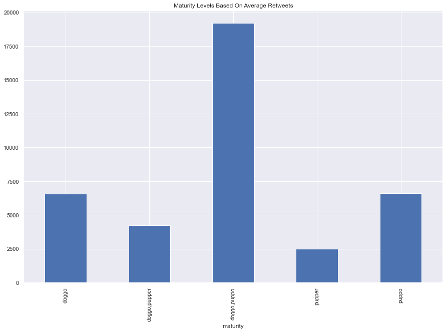

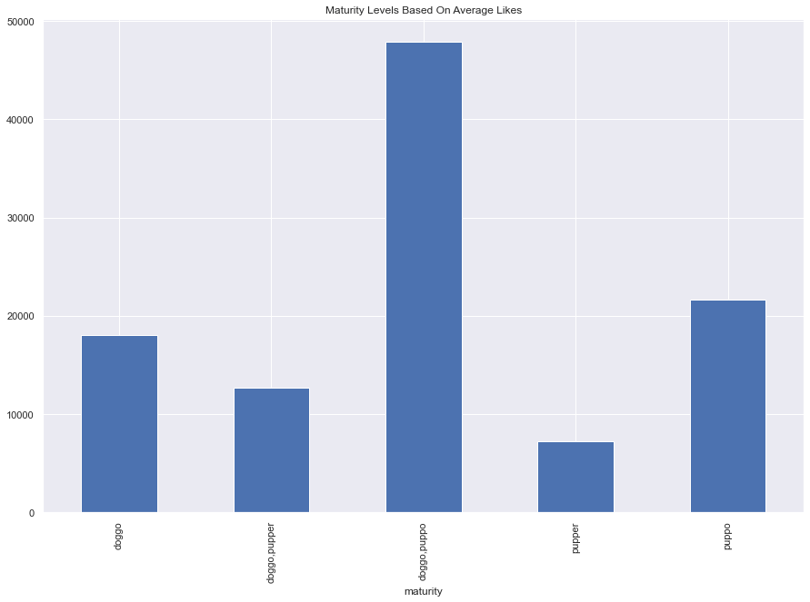

Proved that

- doggo,puppo has the highest number of likes and retweets on average compared to other dog maturity stages
- pupper has the lowest like and retweets per average compared to other maturity stage.

#### Img_num

I noticed that with img_num, tweets with 1 images are more in the dataset used for analysis with **1692** tweets have 1 pictures, **190** having 2, **59** on 3 and 4 img_num have 30 tweets.

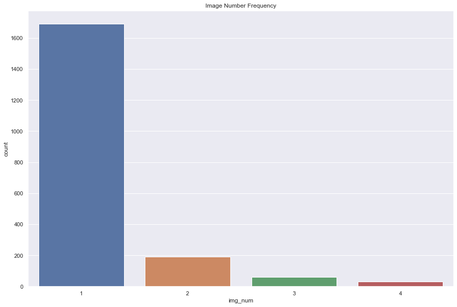

#### Source

With just four sources for the tweets in the dataset, we see a majority from Twitter on iPhone with **1964**, **91** from Vine, **31** from Twitter for Web Client and **11** from TweetDeck

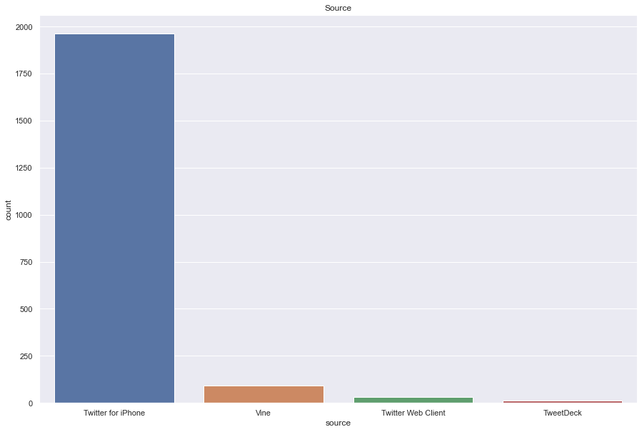